# Compare the Speech of Three Recent President Part 2

# Step 0: check and install needed packages. Load the libraries and functions.

```r
setwd('/Users/bxin66/Dropbox/Columbia/Class3/5243/wk2-TextMining/doc')
library("rvest")
library("tibble")
#library("qdap")
library("sentimentr")
library("gplots")
library("dplyr")
library("syuzhet")
library("factoextra")
library("beeswarm")
library("scales")
library("RColorBrewer")
library("RANN")
library("tm")
library("topicmodels")
source("../lib/plotstacked.R")
source("../lib/speechFuncs.R")
```

# Step 4: data Processing — generate list of sentences

We will use sentences as units of analysis for this project, as sentences are natural languge units for organizing thoughts and ideas. For each extracted sentence, we apply sentiment analysis using [NRC sentiment lexion](http://saifmohammad.com/WebPages/NRC-Emotion-Lexicon.htm). “The NRC Emotion Lexicon is a list of English words and their associations with eight basic emotions (anger, fear, anticipation, trust, surprise, sadness, joy, and disgust) and two sentiments (negative and positive). The annotations were manually done by crowdsourcing.”

We assign an sequential id to each sentence in a speech (`sent.id`) and also calculated the number of words in each sentence as *sentence length* (`word.count`).

## load sentence.list to the disk

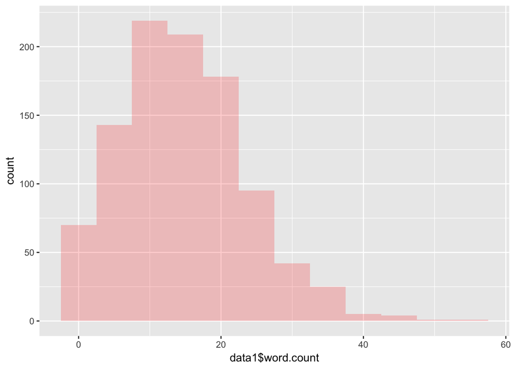

```r
sentence.list  =read.csv("../doc/mySentenceList.csv")
sel.comparison=c("DonaldJTrump", "GeorgeWBush","BarackObama")
sentence.list=sentence.list%>%filter(!is.na(word.count))
sentence.list2 = sentence.list[,c("word.count","File")]
data1=sentence.list2%>%filter(File =="GeorgeWBush")
data2=sentence.list2%>%filter(File =="BarackObama")
data3=sentence.list2%>%filter(File =="DonaldJTrump")


ggplot(data1,aes(x=data1$word.count))  +
    geom_histogram(data=data1,fill = "red", alpha = 0.2,binwidth=5)
```

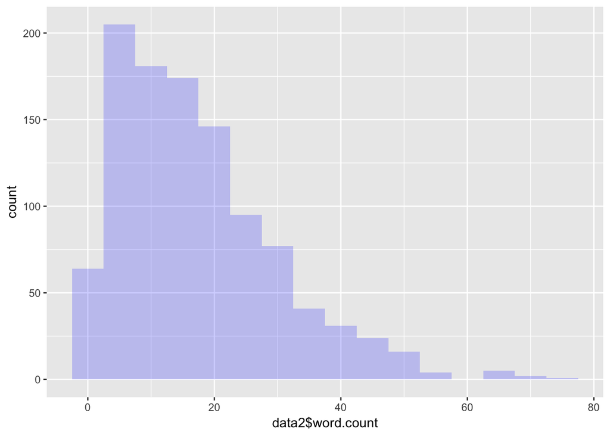

```r
ggplot(data2,aes(x=data2$word.count))  +
   geom_histogram(data=data2,fill = "blue", alpha = 0.2,binwidth=5)
```

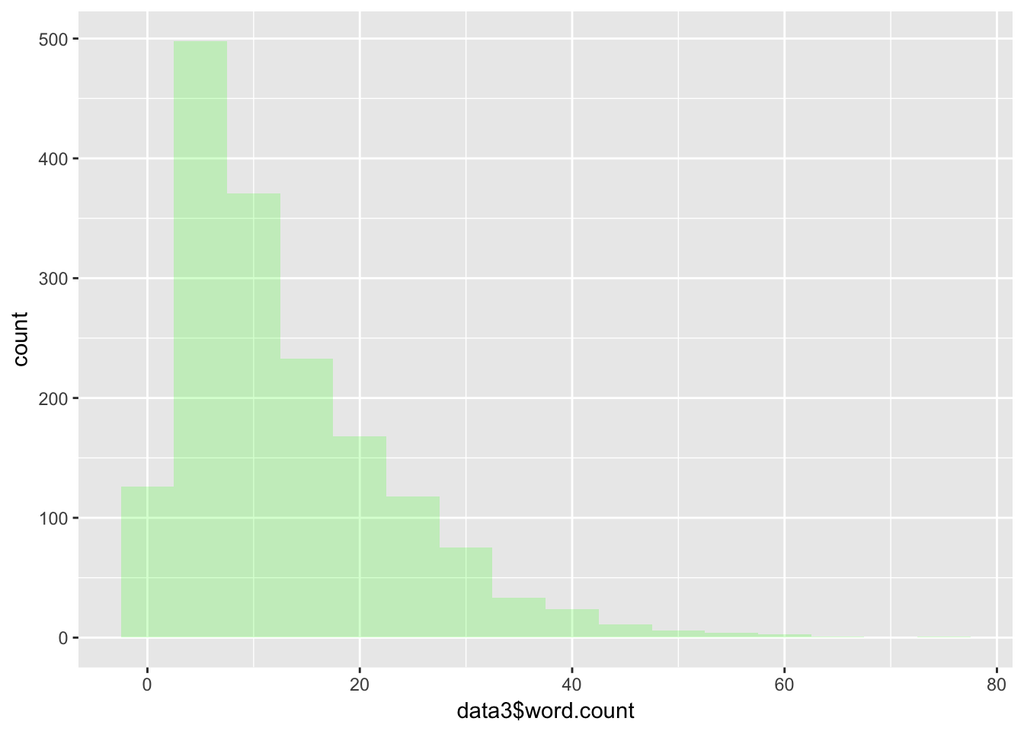

```r
ggplot(data3,aes(x=data3$word.count))  +
    geom_histogram(data=data3,fill = "green", alpha = 0.2,binwidth = 5)
```

# Step 5: Data analysis — Topic modeling

For topic modeling, we prepare a corpus of sentence snipets as follows. For each speech, we start with sentences and prepare a snipet with a given sentence with the flanking sentences. #### according to word counts, create four word clouds one for each selected president and one for them.

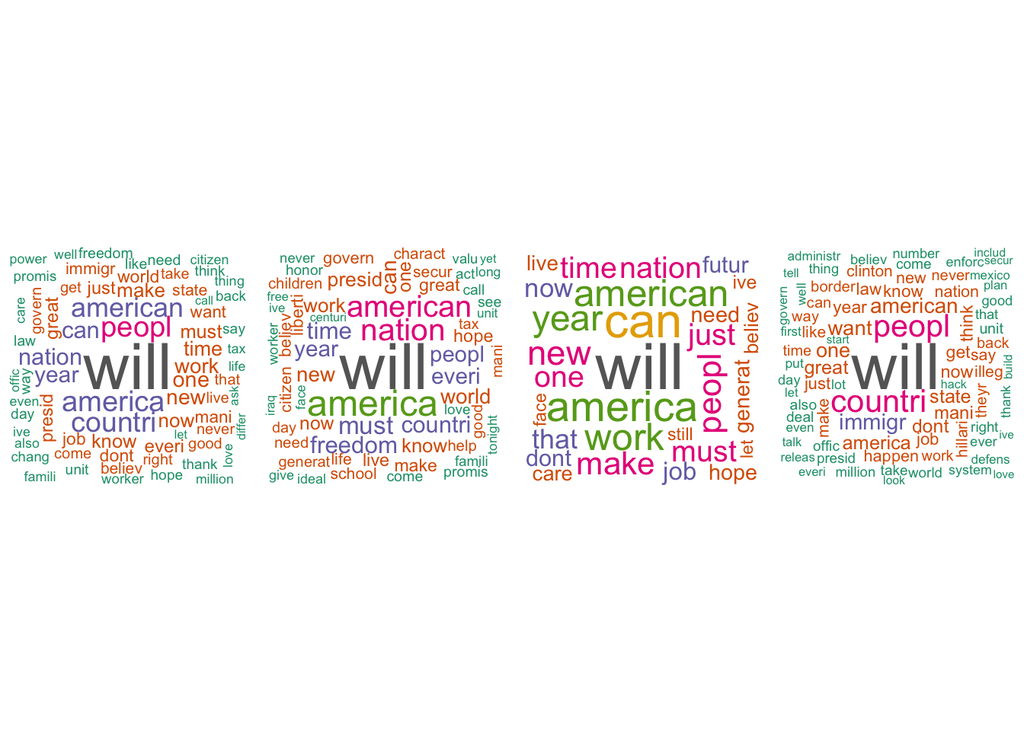

```r
corpus.list=sentence.list[2:(nrow(sentence.list)-1), ]
sentence.pre=sentence.list$sentences[1:(nrow(sentence.list)-2)]
sentence.post=sentence.list$sentences[3:(nrow(sentence.list)-1)]
corpus.list$snipets=paste(sentence.pre, corpus.list$sentences, sentence.post, sep=" ")
rm.rows=(1:nrow(corpus.list))[corpus.list$sent.id==1]
rm.rows=c(rm.rows, rm.rows-1)

corpus.list=corpus.list[-rm.rows, ]
docs <- Corpus(VectorSource(corpus.list$snipets))
docs <-tm_map(docs,content_transformer(tolower))
docs <- tm_map(docs, removePunctuation)
docs <- tm_map(docs, removeNumbers)
docs <- tm_map(docs, removeWords, stopwords("english"))
docs <- tm_map(docs, stripWhitespace)
docs <- tm_map(docs,stemDocument)

library(wordcloud)
library(RColorBrewer)
dtm <- TermDocumentMatrix(docs)
m <- as.matrix(dtm)
v <- sort(rowSums(m),decreasing=TRUE)
d <- data.frame(word = names(v),freq=v)

docs1 <- Corpus(VectorSource(corpus.list%>%filter(File =="GeorgeWBush")%>%select(snipets)))
docs1 <-tm_map(docs1,content_transformer(tolower))
docs1 <- tm_map(docs1, removePunctuation)
docs1 <- tm_map(docs1, removeNumbers)
docs1 <- tm_map(docs1, removeWords, stopwords("english"))
docs1 <- tm_map(docs1, stripWhitespace)
docs1 <- tm_map(docs1,stemDocument)
dtm1 <- TermDocumentMatrix(docs1)
m1 <- as.matrix(dtm1)
v1<- sort(rowSums(m1),decreasing=TRUE)
d1 <- data.frame(word = names(v1),freq=v1)


docs2 <- Corpus(VectorSource(corpus.list%>%filter(File =="BarackObama")%>%select(snipets)))
docs2 <-tm_map(docs2,content_transformer(tolower))
docs2 <- tm_map(docs2, removePunctuation)
docs2 <- tm_map(docs2, removeNumbers)
docs2 <- tm_map(docs2, removeWords, stopwords("english"))
docs <- tm_map(docs2, stripWhitespace)
docs2 <- tm_map(docs2,stemDocument)
dtm2 <- TermDocumentMatrix(docs2)
m2 <- as.matrix(dtm2)
v2<- sort(rowSums(m2),decreasing=TRUE)
d2 <- data.frame(word = names(v2),freq=v2)


docs3 <- Corpus(VectorSource(corpus.list%>%filter(File =="DonaldJTrump")%>%select(snipets)))
docs3 <-tm_map(docs3,content_transformer(tolower))
docs3 <- tm_map(docs3, removePunctuation)
docs3 <- tm_map(docs3, removeNumbers)
docs3 <- tm_map(docs3, removeWords, stopwords("english"))
docs3 <- tm_map(docs3, stripWhitespace)
docs3 <- tm_map(docs3,stemDocument)
dtm3 <- TermDocumentMatrix(docs3)
m3 <- as.matrix(dtm3)
v3<- sort(rowSums(m3),decreasing=TRUE)
d3 <- data.frame(word = names(v3),freq=v3)

par(mfrow=c(1,4))
wordcloud(words = d$word, freq = d$freq, min.freq = 20,max.words=100, random.order=FALSE, colors=brewer.pal(18, "Dark2"))
wordcloud(words = d1$word, freq = d1$freq, min.freq = 20,max.words=100, random.order=FALSE, colors=brewer.pal(18, "Dark2"))
wordcloud(words = d2$word, freq = d2$freq, min.freq = 20,max.words=100, random.order=FALSE, colors=brewer.pal(18, "Dark2"))
wordcloud(words = d3$word, freq = d3$freq, min.freq = 20,max.words=100, random.order=FALSE, colors=brewer.pal(18, "Dark2"))
```

From the output graph we can see they use similar words. According to common sense, we can say the words they use in their speech is the topic (key words) people care most about. They have been selected as president, people still care about the similiar things as 20 years ago.

### Topic modeling

Gengerate document-term matrices.

```r
corpus.list=sentence.list[2:(nrow(sentence.list)-1), ]
sentence.pre=sentence.list$sentences[1:(nrow(sentence.list)-2)]
sentence.post=sentence.list$sentences[3:(nrow(sentence.list)-1)]
corpus.list$snipets=paste(sentence.pre, corpus.list$sentences, sentence.post, sep=" ")
rm.rows=(1:nrow(corpus.list))[corpus.list$sent.id==1]
rm.rows=c(rm.rows, rm.rows-1)

corpus.list=corpus.list[-rm.rows, ]
docs <- Corpus(VectorSource(corpus.list$snipets))
docs <-tm_map(docs,content_transformer(tolower))
docs <- tm_map(docs, removePunctuation)
docs <- tm_map(docs, removeNumbers)
docs <- tm_map(docs, removeWords, stopwords("english"))
docs <- tm_map(docs, stripWhitespace)
docs <- tm_map(docs,stemDocument)
dtm <- DocumentTermMatrix(docs)
#convert rownames to filenames#convert rownames to filenames
rownames(dtm) <- paste(corpus.list$type, corpus.list$File,
                       corpus.list$Term, corpus.list$sent.id, sep="_")
rowTotals <- apply(dtm , 1, sum) #Find the sum of words in each Document
dtm  <- dtm[rowTotals> 0, ]
corpus.list=corpus.list[rowTotals>0, ]
```

Run LDA

```r
#Set parameters for Gibbs sampling
burnin <- 4000
iter <- 2000
thin <- 500
seed <-list(2003,5,63,100001,765)
nstart <- 5
best <- TRUE

#Number of topics
k <- 15

#Run LDA using Gibbs sampling
ldaOut <-LDA(dtm, k, method="Gibbs", control=list(nstart=nstart,
                                                 seed = seed, best=best,
                                                 burnin = burnin, iter = iter,
                                                 thin=thin))
#write out results
#docs to topics
ldaOut.topics <- as.matrix(topics(ldaOut))
table(c(1:k, ldaOut.topics))
```

```
##
##   1   2   3   4   5   6   7   8   9  10  11  12  13  14  15
## 262 250 205 304 183 312 251 191 282 275 284 213 188 213 252
```

```r
write.csv(ldaOut.topics,file=paste("../out/LDAGibbs",k,"DocsToTopics.csv"))

#top 6 terms in each topic
ldaOut.terms <- as.matrix(terms(ldaOut,20))
write.csv(ldaOut.terms,file=paste("../out/LDAGibbs",k,"TopicsToTerms.csv"))

#probabilities associated with each topic assignment
topicProbabilities <- as.data.frame(ldaOut@gamma)
write.csv(topicProbabilities,file=paste("../out/LDAGibbs",k,"TopicProbabilities.csv"))
```

```r
terms.beta=ldaOut@beta
terms.beta=scale(terms.beta)
topics.terms=NULL
for(i in 1:k){
  topics.terms=rbind(topics.terms, ldaOut@terms[order(terms.beta[i,], decreasing = TRUE)[1:7]])
}
topics.terms
```

```
##       [,1]        [,2]       [,3]      [,4]            [,5]
##  [1,] "yes"       "teacher"  "grant"   "math"          "regardless"
##  [2,] "judgment"  "opinion"  "petti"   "patient"       "outlook"
##  [3,] "growth"    "airport"  "selma"   "infrastructur" "exclus"
##  [4,] "break"     "bill"     "invest"  "corpor"        "code"
##  [5,] "woman"     "sacrific" "career"  "food"          "apart"
##  [6,] "crime"     "visa"     "deport"  "death"         "prioriti"
##  [7,] "terrorist" "foreign"  "nuclear" "refus"         "missil"
##  [8,] "move"      "exist"    "product" "advantag"      "nafta"
##  [9,] "vet"       "blame"    "repeal"  "amend"         "intend"
## [10,] "liberti"   "act"      "advanc"  "task"          "tradit"
## [11,] "hack"      "news"     "drug"    "horribl"       "sad"
## [12,] "word"      "moment"   "faith"   "dream"         "stori"
## [13,] "great"     "mexico"   "involv"  "especi"        "probabl"
## [14,] "see"       "heard"    "rather"  "brought"       "wound"
```

[output cut: 17 more lines]

```r
ldaOut.terms
```

```
##       Topic 1    Topic 2      Topic 3   Topic 4    Topic 5   Topic 6
##  [1,] "can"      "time"       "will"    "new"      "work"    "immigr"
##  [2,] "must"     "now"        "america" "job"      "one"     "law"
##  [3,] "govern"   "chang"      "make"    "tax"      "famili"  "offic"
##  [4,] "children" "even"       "togeth"  "worker"   "give"    "illeg"
##  [5,] "school"   "long"       "protect" "care"     "live"    "border"
##  [6,] "respons"  "differ"     "build"   "pay"      "home"    "system"
##  [7,] "help"     "hope"       "serv"    "economi"  "better"  "enforc"
##  [8,] "make"     "face"       "safe"    "health"   "hard"    "number"
##  [9,] "live"     "end"        "strong"  "reform"   "share"   "million"
## [10,] "valu"     "wont"       "choic"   "creat"    "watch"   "administr"
## [11,] "program"  "washington" "use"     "compani"  "still"   "stop"
## [12,] "need"     "challeng"   "fail"    "million"  "everyon" "crimin"
## [13,] "lead"     "whether"    "rebuild" "secur"    "hope"    "danger"
## [14,] "child"    "begin"      "follow"  "billion"  "digniti" "communiti"
```

[output cut: 48 more lines]

Based on the most popular terms and the most salient terms for each topic, we assign a hashtag to each topic. This part require manual setup as the topics are likely to change.

```r
topics.hash=c("Economy", "America", "Defense", "Belief", "Election", "Patriotism", "Unity", "Government", "Reform", "Temporal", "WorkingFamilies", "Freedom", "Equality", "Misc", "Legislation")
corpus.list$ldatopic=as.vector(ldaOut.topics)
corpus.list$ldahash=topics.hash[ldaOut.topics]

colnames(topicProbabilities)=topics.hash
corpus.list.df=cbind(corpus.list, topicProbabilities)
```

## Clustering of topics

```r
par(mar=c(1,1,1,1))
topic.summary=tbl_df(corpus.list.df)%>%
              filter(type%in%c("nomin", "inaug"), File%in%sel.comparison)%>%
              select(File, Economy:Legislation)%>%
              group_by(File)%>%
              summarise_each(funs(mean))
```

```
## `summarise_each()` is deprecated.
## Use `summarise_all()`, `summarise_at()` or `summarise_if()` instead.
## To map `funs` over all variables, use `summarise_all()`
```

```r
topic.summary=as.data.frame(topic.summary)
rownames(topic.summary)=topic.summary[,1]

topic.plot=c(1, 13, 9, 11, 8, 3, 7)
print(topics.hash[topic.plot])
```

```
## [1] "Economy"         "Equality"        "Reform"          "WorkingFamilies"
## [5] "Government"      "Defense"         "Unity"
```

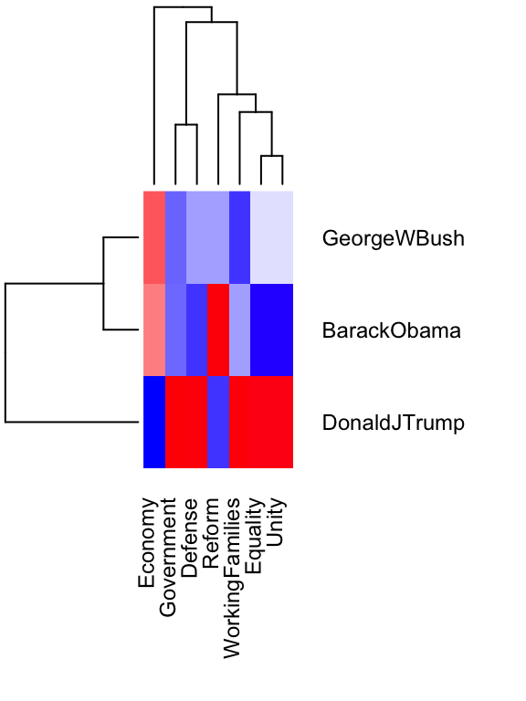

```r
heatmap.2(as.matrix(topic.summary[,topic.plot+1]),
          scale = "column", key=F,
          col = bluered(100),
          cexRow = 0.9, cexCol = 0.9, margins = c(8, 8),
          trace = "none", density.info = "none")
```

```r
# [1] "Economy"         "America"         "Defense"         "Belief"
# [5] "Election"        "Patriotism"      "Unity"           "Government"
# [9] "Reform"          "Temporal"        "WorkingFamilies" "Freedom"
# [13] "Equality"        "Misc"            "Legislation"


par(mfrow=c(3, 1), mar=c(1,1,2,0), bty="n", xaxt="n", yaxt="n")

topic.plot=c(1, 13, 14, 15, 8, 9, 12)
print(topics.hash[topic.plot])
```

```
## [1] "Economy"     "Equality"    "Misc"        "Legislation" "Government"
## [6] "Reform"      "Freedom"
```

```r
speech.df=tbl_df(corpus.list.df)%>%filter(File=="GeorgeWBush", type=="nomin", Term==1)%>%select(sent.id, Economy:Legislation)
speech.df=as.matrix(speech.df)
speech.df[,-1]=replace(speech.df[,-1], speech.df[,-1]<1/15, 0.001)
plot.stacked(speech.df[,1], speech.df[,topic.plot+1],
            xlab="Sentences", ylab="Topic share", main="George W Bush, Nomination")
```

```
## [1] 0.06920567 0.13841134 0.20761701 0.27682268 0.34602834 0.41523401
## [7] 0.48443968
```

```r
speech.df=tbl_df(corpus.list.df)%>%filter(File=="BarackObama", type=="nomin", Term==1)%>%select(sent.id, Economy:Legislation)
speech.df=as.matrix(speech.df)
speech.df[,-1]=replace(speech.df[,-1], speech.df[,-1]<1/15, 0.001)
plot.stacked(speech.df[,1], speech.df[,topic.plot+1],
            xlab="Sentences", ylab="Topic share", main="Barack Obama, Nomination")
```

```
## [1] 0.06520766 0.13041532 0.19562297 0.26083063 0.32603829 0.39124595
## [7] 0.45645360
```

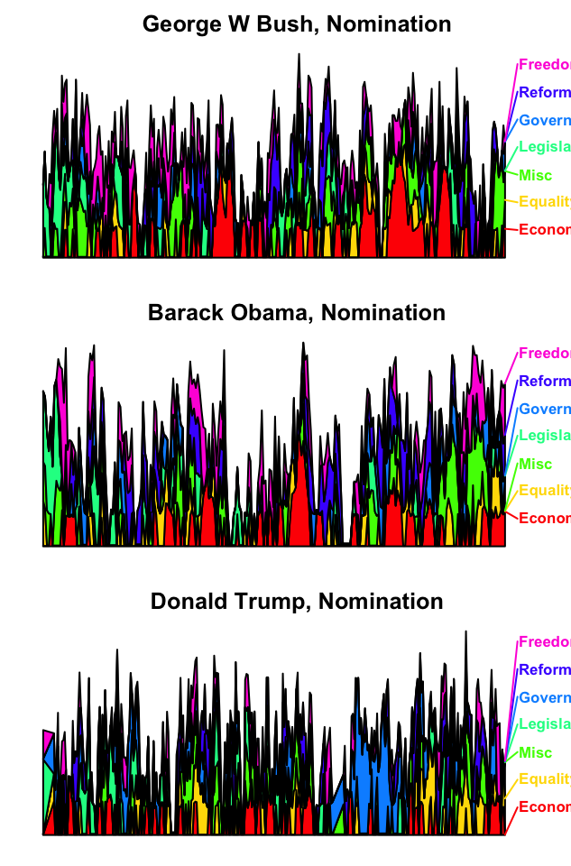

```
## [1] 0.06903681 0.13807363 0.20711044 0.27614725 0.34518407 0.41422088
## [7] 0.48325769
```

```r
speech.df=tbl_df(corpus.list.df)%>%filter(File=="DonaldJTrump", type=="nomin")%>%select(sent.id, Economy:Legislation)
speech.df=as.matrix(speech.df)
speech.df[,-1]=replace(speech.df[,-1], speech.df[,-1]<1/15, 0.001)
plot.stacked(speech.df[,1], speech.df[,topic.plot+1],
            xlab="Sentences", ylab="Topic share", main="Donald Trump, Nomination")
```

```r
speech.df=tbl_df(corpus.list.df)%>%filter(type=="nomin", word.count<20)%>%select(sentences, Economy:Legislation)
names(speech.df)[-1]
```

```
##  [1] "Economy"         "America"         "Defense"
##  [4] "Belief"          "Election"        "Patriotism"
##  [7] "Unity"           "Government"      "Reform"
## [10] "Temporal"        "WorkingFamilies" "Freedom"
## [13] "Equality"        "Misc"            "Legislation"
```